# b_heart_mediannorm_medianpolish

Author

Affiliation

Lieven Clement

Ghent University

# 1 Heart use case: a MaxQuant LFQ DDA dataset with a more complex design

## 1.1 Introduction

In this chapter we show how to analyse LFQ data from an experiment with a more complex design. The data are a small subset of the public dataset PXD006675 on PRIDE.

Particularly, the proteomes of the atrium and ventriculum in the left and the right heart region are profiled for 3 patients (identifiers 3, 4, and 8). Hence, the design consists of a factor tissue (atrium, ventriculum), region (left, right) and block (patient 3,4, and 8).

Suppose that researchers are mainly interested in comparing the ventricular to the atrial proteome. Particularly, they would like to compare the left atrium to the left ventricle, the right atrium to the right ventricle, the average ventricular vs atrial proteome and if ventricular vs atrial proteome shifts differ between left and right heart region.

## 1.2 Load packages

First, we load the `msqrob2` package and additional packages for data manipulation and visualisation.

```r
suppressPackageStartupMessages({
library("QFeatures")
library("dplyr")
library("tidyr")
library("ggplot2")
library("msqrob2")
library("stringr")
library("ExploreModelMatrix")
library("kableExtra")
library("ComplexHeatmap")
library("scater")
library("patchwork")
})
```

We also configure the parallelisation framework.

```r
library("BiocParallel")
register(SerialParam())
```

## 1.3 Load Data

### 1.3.1 Getting the data

The data were searched with MaxQuant version 1.5.5.6 and are deposited on the PRIDE repository PXD006675.

In this chapter we use a small subset of the data that is available on msqrob2data.

```r
library("BiocFileCache")
bfc <- BiocFileCache()
peptideFile <- bfcrpath(bfc, "https://github.com/statOmics/msqrob2data/raw/refs/heads/main/dda/heart/peptides.txt")
```

After downloading the files, we can load the peptide table, which is in “wide format”. Hence, each row represents a single peptide and each quantification column (that starts with `"Intensity"`) represents a single sample.

```r
peptides <- data.table::fread(peptideFile, check.names = TRUE, integer64 = "double")
quantcols <- grep("Intensity[.]", names(peptides), value = TRUE)
```

| Sequence | N.term.cleavage.window | C.term.cleavage.window | Amino.acid.before | First.amino.acid | Second.amino.acid | Second.last.amino.acid | Last.amino.acid | Amino.acid.after | A.Count | R.Count | N.Count | D.Count | C.Count | Q.Count | E.Count | G.Count | H.Count | I.Count | L.Count | K.Count | M.Count | F.Count | P.Count | S.Count | T.Count | W.Count | Y.Count | V.Count | U.Count | … |
| --- | --- | --- | --- | --- | --- | --- | --- | --- | --- | --- | --- | --- | --- | --- | --- | --- | --- | --- | --- | --- | --- | --- | --- | --- | --- | --- | --- | --- | --- | --- |
| AAAAAAAAAK | AKFRKQERAAAAAAAA | AAAAAAAKNGSSGKKS | R | A | A | A | K | N | 9 | 0 | 0 | 0 | 0 | 0 | 0 | 0 | 0 | 0 | 0 | 1 | 0 | 0 | 0 | 0 | 0 | 0 | 0 | 0 | 0 | … |
| AAAAAAAAEQQSSNGPVK | ________________ | QSSNGPVKKSMREKAV | M | A | A | V | K | K | 8 | 0 | 1 | 0 | 0 | 2 | 1 | 1 | 0 | 0 | 0 | 1 | 0 | 0 | 1 | 2 | 0 | 0 | 0 | 1 | 0 | … |
| AAAAAAAAGAFAGR | APLLGARRAAAAAAAA | AAGAFAGRRAACGAVL | R | A | A | G | R | R | 10 | 1 | 0 | 0 | 0 | 0 | 0 | 2 | 0 | 0 | 0 | 0 | 0 | 1 | 0 | 0 | 0 | 0 | 0 | 0 | 0 | … |
| AAAAAAAPEPPLGLQQLSALQPEPGGVPLHSSWTFWLDR | AREPPGSRAAAAAAAP | SWTFWLDRSLPGATAA | R | A | A | D | R | S | 8 | 1 | 0 | 1 | 0 | 3 | 2 | 3 | 1 | 0 | 6 | 0 | 0 | 1 | 6 | 3 | 1 | 2 | 0 | 1 | 0 | … |
| AAAAAAGAASGLPGPVAQGLK | ________________ | GPVAQGLKEALVDTLT | M | A | A | L | K | E | 9 | 0 | 0 | 0 | 0 | 1 | 0 | 4 | 0 | 0 | 2 | 1 | 0 | 0 | 2 | 1 | 0 | 0 | 0 | 1 | 0 | … |
| AAAAAATAPPSPGPAQPGPR | AAPARAPRAAAAAATA | GPAQPGPRAQRAAPLA | R | A | A | P | R | A | 8 | 1 | 0 | 0 | 0 | 1 | 0 | 2 | 0 | 0 | 0 | 0 | 0 | 0 | 6 | 1 | 1 | 0 | 0 | 0 | 0 | … |

We now extract the sample annotations. We will build a table where each row in the annotation table contains information for one sample (the table below shows the first 6 rows). This information is extracted from the sample names.

```r
coldata <- data.frame(quantCols = quantcols) |>
  mutate(sampleId = gsub("Intensity[.]", "", quantcols),
         location  = substr(sampleId, 1, 1), # heart region left-right
         tissue  = substr(sampleId, 2, 2), # tissue Atrium-Ventriculum
         patient  = substr(sampleId, 3, 3)) # patient id
```

| quantCols | sampleId | location | tissue | patient |
| --- | --- | --- | --- | --- |
| Intensity.LA3 | LA3 | L | A | 3 |
| Intensity.LA4 | LA4 | L | A | 4 |
| Intensity.LA8 | LA8 | L | A | 8 |
| Intensity.LV3 | LV3 | L | V | 3 |
| Intensity.LV4 | LV4 | L | V | 4 |
| Intensity.LV8 | LV8 | L | V | 8 |

### 1.3.2 The `QFeatures` data class

We combine the two tables into a `QFeatures` object.

```r
(pe <- readQFeatures(
  peptides, colData = coldata, fnames = "Sequence", name = "peptides"
))
```

```
Checking arguments.
```

```
Loading data as a 'SummarizedExperiment' object.
```

```
Formatting sample annotations (colData).
```

```
Formatting data as a 'QFeatures' object.
```

```
Setting assay rownames.
```

```
An instance of class QFeatures (type: bulk) with 1 set:

 [1] peptides: SummarizedExperiment with 31319 rows and 12 columns
```

## 1.4 Data preprocessing

`msqrob2` relies on the `QFeatures` data structure, meaning that we can directly make use of `QFeatures`’ data preprocessing functionality (see also the `QFeatures` [documentation](https://rformassspectrometry.github.io/QFeatures/articles/Processing.html)).

### 1.4.1 Encoding missing values

Peptides with zero intensities should be encoded using `NA`.

```r
pe <- zeroIsNA(pe, "peptides")
```

We calculate how many non zero intensities we have per peptide and this is often useful for filtering.

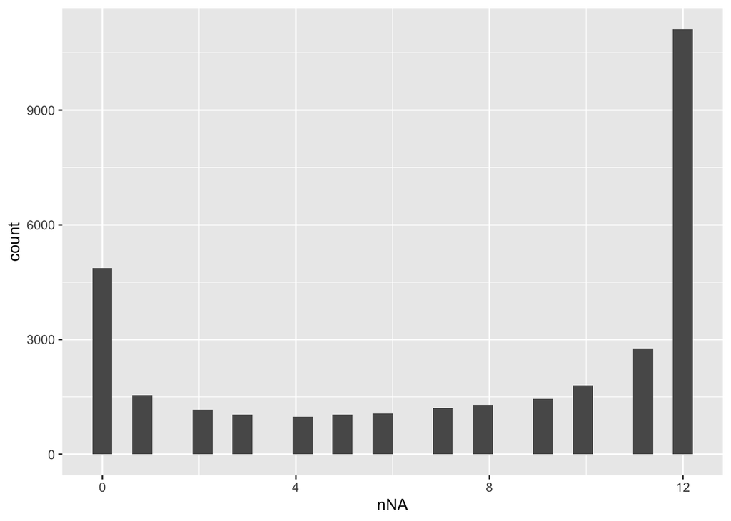

```r
naResults <- nNA(pe, "peptides")
data.frame(naResults$nNArows) |>
  ggplot() +
  aes(x = nNA) +
  geom_histogram()
```

### 1.4.2 PSM filtering

We filter features based on 3 criteria (see PSM filtering).

1. Remove failed protein inference

We remove peptides that could not be uniquely mapped to a protein.

```r
pe <- filterFeatures(pe,
  ~ Proteins != "" & ## Remove failed protein inference
    !grepl(";", Proteins)) ## Remove protein groups
```

```
'Proteins' found in 1 out of 1 assay(s).
```

2. Remove reverse sequences (decoys) and contaminants

We remove the contaminants and peptides that map to decoy sequences. These features bear no information of interest and will reduce the statistical power upon multiple test adjustment.

```r
pe <- filterFeatures(pe, ~ Reverse != "+" & Potential.contaminant != "+")
```

```
'Reverse' found in 1 out of 1 assay(s).'Potential.contaminant' found in 1 out of 1 assay(s).
```

3. Remove highly missing peptides.

We keep peptides that were observed at least 3 times out of the $n = 12$ samples, so we tolerate the following proportion of NAs: $\text{pNA} = \frac{(n - 3)}{n} = 0.75$, so we keep peptides that are observed in at least 25% of the samples.

```r
nObs <- 3
n <- ncol(pe[["peptides"]])
(pe <- filterNA(pe, i = "peptides", pNA = (n - nObs) / n))
```

```
An instance of class QFeatures (type: bulk) with 1 set:

 [1] peptides: SummarizedExperiment with 15630 rows and 12 columns
```

We keep 15630 peptides upon filtering.

### 1.4.3 Identifications per sample

[output not shown]

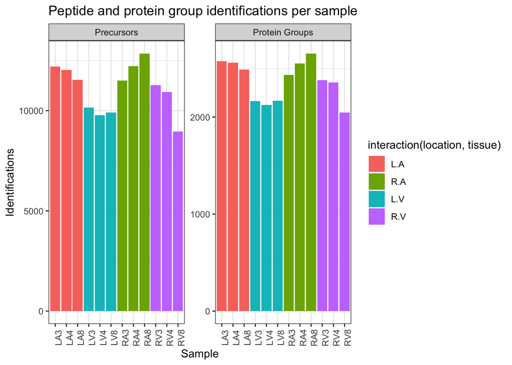

```r
pe[,,"peptides"] |>
  longForm(colvars = colnames(colData(pe)),
           rowvars= c("Sequence",
                      "Proteins")) |>
  data.frame() |>
  filter(!is.na(value)) |>
  group_by(location, tissue, sampleId) |>
  summarise(Precursors = length(unique(Sequence)),
            `Protein Groups` = length(unique(Proteins))) |>
  pivot_longer(-(1:3),
               names_to = "Feature",
               values_to = "IDs") |>
  ggplot(aes(x = sampleId, y = IDs, fill = interaction(location,tissue))) +
  geom_col() +
  #scale_fill_observable() +
  facet_wrap(~Feature,
             scales = "free_y") +
  labs(title = "Peptide and protein group identifications per sample",
       x = "Sample",
       y = "Identifications") +
  theme_bw() +
  theme(axis.text.x = element_text(angle = 90))
```

There are rather large variations in the peptide and protein identifications across samples. Therefore we will normalise the data using the median method, which centers each sample by subtracting its median log2 intensity so that all samples are aligned to a common location.

### 1.4.4 Standard preprocessing workflow

We can now prepare the data for modelling. The workflow ensures the data complies to `msqrob2`’s requirements:

1. Intensities are log-transformed.

```r
pe <- logTransform(pe, base = 2, i = "peptides", name = "peptides_log")
```

2. Normalisation with Median method.

```r
pe <- sweep( #Subtract log2 norm factor column-by-column (MARGIN = 2)
  pe,
  MARGIN = 2,
  STATS = nfLogMedian(pe,i = "peptides_log",na.rm = TRUE),
  i = "peptides_log",
  name = "peptides_norm"
)
```

```
This function aims to calculate norm factors on a log scale,
          the input data are assumed to be on the log-scale!
```

Upon the normalisation the density curves should be nicely centred. To confirm this, we will plot the intensity distributions for each biorepeat (patient). `longForm()` seamlessly combines the quantification and annotation data into a table suitable for `ggplot2` visualisation. We also subset the object with the data before and after normalisation.

```
harmonizing input:
  removing 12 sampleMap rows not in names(experiments)
```

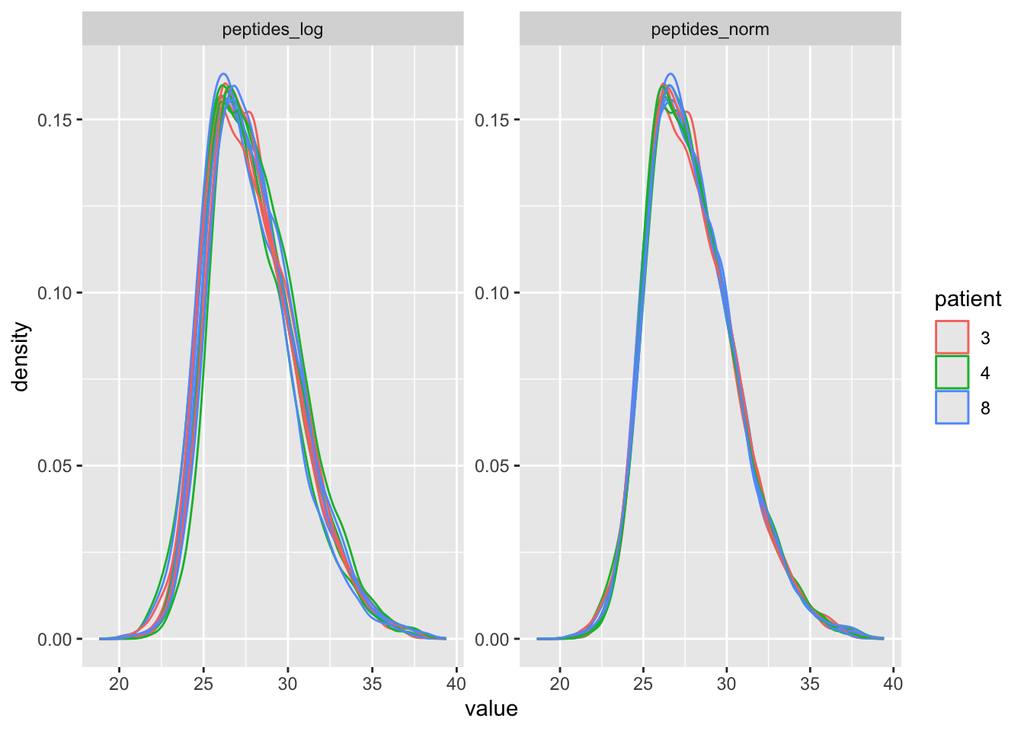

```r
longForm(pe[, , c("peptides_log", "peptides_norm")], colvar = "patient") |>
  ggplot() +
  aes(x = value, group = colname, color = patient) +
  geom_density() +
  facet_wrap(~ assay, scale = "free")
```

3. Summarisation to protein level.

We use the robust summary approach to infer protein-level data from peptide-level data, accounting for the fact that different peptides have ionisation efficiencies hence leading to different intensity baselines. As the robust summarisation takes a while we shift to medianPolish in this dataset.

```r
pe <- aggregateFeatures(
  pe, i = "peptides_norm", fcol = "Proteins",
  fun = MsCoreUtils::medianPolish,
  na.rm = TRUE, name = "proteins"
)
```

```
The following messages occurred during aggregation:
```

```
Your quantitative and row data contain missing values. Please read the
relevant section(s) in the aggregateFeatures manual page regarding the
effects of missing values on data aggregation.

Occurred during the aggregation of set(s): peptides
```

## 1.5 Data exploration

We will explore the main sources of variation in the data using MDS.

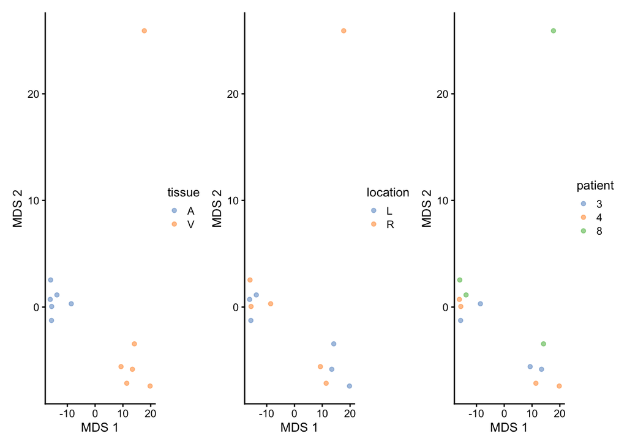

```r
library("scater")
se <- getWithColData(pe, "proteins") |>
  as("SingleCellExperiment") |>
  runMDS(exprs_values = 1)
plotMDS(se, colour_by = "tissue") +
  plotMDS(se, colour_by = "location") +
  plotMDS(se, colour_by = "patient")
```

## 1.6 Data modelling

The preprocessed data can now be modelled to answer biologically relevant questions. Particularly, the protein abundance can differ according to tissue type (A-V) and location (L-R). Moreover, the effect of the tissue type can differ according to the location and vice versa. Hence, there can be an interaction between tissue and location.

The samples are also not independent as four biopsies (LA, RA, LV and RV) were taken for each patient. Because the proteome is profiled for each tissue x location combination within each patient, the design is a randomised complete block (RCB) design.

RCB designs can be correctly analysed by incorporating the block effect for patient either as a fixed or a random effect. The use of a fixed patient effect is here also possible because the effect of each factor combination can be estimated within block (patient).

Here, we choose to account for the patient effect using fixed effects because mixed models are computationally more demanding and rely on asymptotic inference (i.e. statistical inference is only valid for experiments with large sample sizes).

Now we have identified the sources of variation in the experiment that we have to account for (tissue, location and patient id), we can define a model.

```r
model <- ~ location*tissue + ## (1) fixed effects: main effects for location and tissue type, and a tissue x location interaction
  patient  ## (2) fixed block effect for patient
```

### 1.6.1 Estimate the model

We estimate the model with `msqrob()`. Recall that variables defined in `model` are automatically retrieved from the `colData` (i.e. `"tissue"`, `"location"`, and `"patient"`).

```r
pe <- msqrob(
  pe, i = "proteins", formula = model, robust = TRUE
)
```

## 1.7 Statistical inference

Once the models are estimated, we can start answering biological questions by performing Statistical inference. We must translate the biological questions into a statistical hypotheses:

1. Is there an effect of tissue type (V-A) in the left heart region?
2. Is there an effect of tissue type (V-A) in the right heart region?
3. Is there on average an effect of tissue type in the heart.
4. Does the effect of tissue type (V-A) differ according to the heart region (L-R)?

In other words, we must translate these questions in a linear combination of the model parameters, also referred to as a contrast. To aid defining contrasts, we will visualise the experimental design using the `ExploreModelMatrix` package.

```
$`location = L`
```

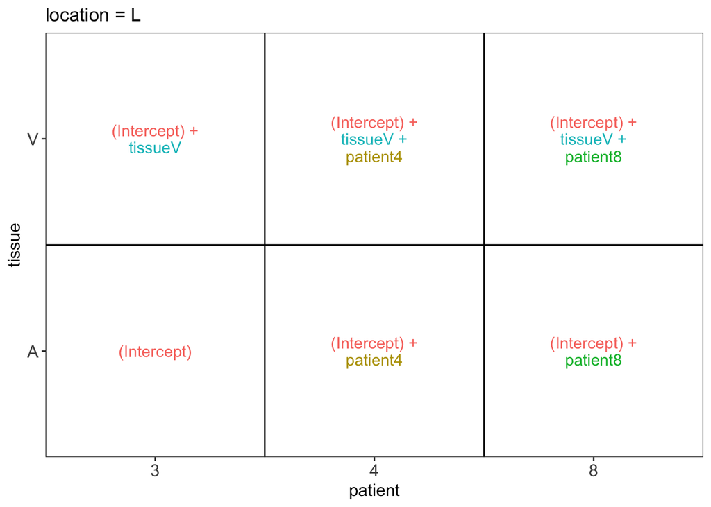

```
$`location = R`
```

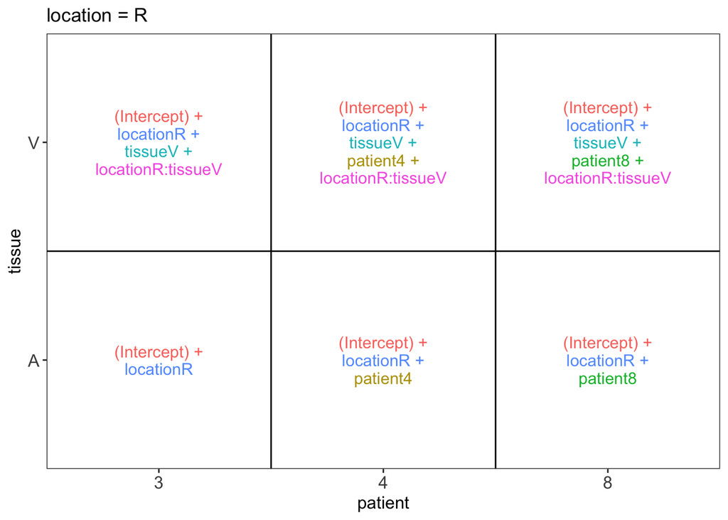

```r
library("ExploreModelMatrix")
vd <- VisualizeDesign(
    sampleData =  colData(pe),
    designFormula = ~ location*tissue + patient,
    textSizeFitted = 4
)
vd$plotlist
```

### 1.7.1 Research question 1: is there an effect of tissue in the left heart region?

From the plot we can see that the average log2 intensity for patient 3 in the left ventriculum equals `(Intercept) + tissueV`:

$$\mu^L_{V,3} = \beta_0 + \beta_V$$
and for the left atrium `(Intercept)`:

$$\mu^L_{A,3} = \beta_0$$
So the average $\log_2 FC$ between atrium and ventriculum for patient 3 equals to parameter `tissueV`

$$\log_2 FC_{V-A}^L = \mu^L_{V,3} -\mu^L_{A,3} = \beta_V$$
The same can be seen for patient 4:

$$\log_2 FC_{V-A}^L= \mu^L_{V,4} -\mu^L_{A,4} = \beta_0 + \beta_V + \beta_4 - (\beta_0 + \beta_4) = \beta_V$$
So the parameter `tissueV` has the interpretation of the average $\log_2 FC$ between ventriculum and atrium after correction for the patient effect, which quantifies the effect size for the first research hypothesis.

### 1.7.2 Research question 2: is there an effect of tissue in the right heart region?

When we use the same rationale for the right heart region, we can see that the average $\log_2 FC$ between atrium and ventriculum upon correction for the patient effect equals `tissueV + locationR:tissueV`. So, it consists of the main effect for tissue and the location x tissue interaction.

We will illustrate this here for patient 4:

$$\begin{array}{rcl}
\log_2 FC_{V-A}^R& =&\mu^R_{V,4} -\mu^R_{A,4} \\
&=& \beta_0 +
\beta_R + \beta_V + \beta_{R:V} + \beta_4 - (\beta_0 +
\beta_R + \beta_4) \\
&=& \beta_V + \beta_{R:V}
\end{array}$$

### 1.7.3 Research question 3: is there an effect of tissue on average in the heart?

This research question can be quantified by calculating the averaging the $\log_2$ fold change between Ventriculum and Atrium over the left and right heart regions, which equals `tissueV + 0.5*locationR:tissueV`

$$\begin{array}{rcl}
(\log_2 FC_{V-A}^L + \log_2 FC_{V-A}^R)/ 2 &=& (\beta_V + \beta_V + \beta_{R:V})/2 \\
&=& \beta_V + 0.5\times\beta_{R:V}
\end{array}$$

### 1.7.4 Research question 4: does the effect of tissue differ according to the heart region?

This research question can be quantified by calculating the difference in the $\log_2$ fold change between Ventriculum and Atrium in the right and left heart regions, which equals `locationR:tissueV`

$$\begin{array}{rcl}
\log_2 FC_{V-A}^R- \log_2 FC_{V-A}^L &=& \beta_V + \beta_{R:V}-\beta_V \\
&=& \beta_{R:V}
\end{array}$$
### Setting up the contrasts

We can set up the four contrasts:

1. We make the design matrix so that we can easily extract all parameter names from the model
2. We make the contrast matrix for the four contrasts

```r
L <- makeContrast(
  c(
    "tissueV = 0",
    "tissueV + locationR:tissueV = 0",
    "tissueV + 0.5*locationR:tissueV = 0",
    "locationR:tissueV = 0"
  ),
  parameterNames = colnames(vd$designmatrix)
  )
```

We can now falsify the null hypothesis of each contrast:

```r
pe <- hypothesisTest(
  object = pe, i = "proteins", contrast = L
)
```

### 1.7.5 Results tables for significant proteins

We first collect the results for all contrasts.

```r
inferences <-
  msqrobCollect(pe[["proteins"]], L)
head(inferences)
```

```
                     logFC        se       df          t      pval   adjPval
tissueV.A0PJW6  0.46100784 0.5817309 8.425498  0.7924761 0.4498194 0.6603534
tissueV.A0PJZ3  0.00000000        NA       NA         NA        NA        NA
tissueV.A0PK00          NA        NA       NA         NA        NA        NA
tissueV.A1A4S6  0.06833739 0.3014249 8.867620  0.2267145 0.8257856 0.9069296
tissueV.A1A5D9          NA        NA       NA         NA        NA        NA
tissueV.A1IGU5 -0.48805525 0.3373626 9.433948 -1.4466786 0.1803821 0.4005632
               contrast feature
tissueV.A0PJW6  tissueV  A0PJW6
tissueV.A0PJZ3  tissueV  A0PJZ3
tissueV.A0PK00  tissueV  A0PK00
tissueV.A1A4S6  tissueV  A1A4S6
tissueV.A1A5D9  tissueV  A1A5D9
tissueV.A1IGU5  tissueV  A1IGU5
```

Next, we will return tables of proteins for which the contrasts are significant at the 5% FDR level.

1. We set the significance level
2. We loop over the contrasts
3. We filter the significant results for the contrast from the table
4. We print the table

```r
alpha <- 0.05 #1.
for (contrasti in colnames(L)) #2.
{
  sigList <- inferences |>
    filter(contrast == contrasti & adjPval < alpha) #3.
  cat("**Contrast:**", contrasti, "= 0 (", nrow(sigList), " significant proteins)\n\n") #4.
  print(kable(sigList, row.names = FALSE) |>
      kable_styling(full_width = FALSE) |>
      scroll_box(height = "250px")
      ) #4.
  cat("\n\n\n---\n\n") #4.
}
```

**Contrast:** tissueV = 0 ( 142 significant proteins)

| logFC | se | df | t | pval | adjPval | contrast | feature |
| --- | --- | --- | --- | --- | --- | --- | --- |
| -2.256330 | 0.5389209 | 9.433948 | -4.186756 | 0.0021212 | 0.0392162 | tissueV | A6NMZ7 |
| -4.247351 | 0.7727317 | 8.433948 | -5.496541 | 0.0004795 | 0.0194140 | tissueV | O00180 |
| -1.861782 | 0.4070922 | 9.135478 | -4.573367 | 0.0012896 | 0.0299875 | tissueV | O00264 |
| -2.378569 | 0.3418984 | 9.391022 | -6.956947 | 0.0000537 | 0.0091190 | tissueV | O14967 |
| -3.292729 | 0.7152737 | 6.433948 | -4.603453 | 0.0030760 | 0.0457557 | tissueV | O15116 |
| -1.256215 | 0.3169899 | 9.273478 | -3.962951 | 0.0031005 | 0.0457831 | tissueV | O15230 |
| -1.883608 | 0.3699968 | 9.284261 | -5.090877 | 0.0005929 | 0.0218082 | tissueV | O43464 |
| -2.699229 | 0.4650152 | 8.518026 | -5.804603 | 0.0003181 | 0.0162008 | tissueV | O43677 |
| -1.531385 | 0.3672999 | 8.696175 | -4.169304 | 0.0026023 | 0.0425067 | tissueV | O60262 |
| -3.570879 | 0.6574253 | 8.433948 | -5.431611 | 0.0005195 | 0.0202110 | tissueV | O60760 |
| -2.155661 | 0.3044861 | 9.433948 | -7.079669 | 0.0000456 | 0.0091190 | tissueV | O75368 |
| -1.554408 | 0.3592891 | 8.577180 | -4.326343 | 0.0021438 | 0.0392162 | tissueV | O75746 |
| -1.566930 | 0.3820714 | 9.433948 | -4.101144 | 0.0024192 | 0.0418099 | tissueV | O75828 |
| 2.385249 | 0.3316354 | 9.243472 | 7.192384 | 0.0000446 | 0.0091190 | tissueV | O94875-10 |
| -4.138829 | 0.5582860 | 5.433948 | -7.413455 | 0.0004872 | 0.0194140 | tissueV | O95631 |
| -2.025355 | 0.2966728 | 9.433948 | -6.826897 | 0.0000610 | 0.0093350 | tissueV | O95865 |
| -2.236033 | 0.4604501 | 8.773904 | -4.856190 | 0.0009688 | 0.0296708 | tissueV | O95980 |
| -2.086787 | 0.3237275 | 9.069401 | -6.446122 | 0.0001147 | 0.0100149 | tissueV | P00325 |
| -1.741370 | 0.4140971 | 9.414309 | -4.205220 | 0.0020717 | 0.0392162 | tissueV | P00748 |
| -1.284520 | 0.2891255 | 8.801787 | -4.442777 | 0.0017079 | 0.0352561 | tissueV | P01031 |
| -1.750032 | 0.4337484 | 8.975541 | -4.034670 | 0.0029687 | 0.0454460 | tissueV | P01034 |
| -4.295755 | 0.6894564 | 6.342953 | -6.230640 | 0.0006379 | 0.0226383 | tissueV | P01699 |
| -2.657562 | 0.3896795 | 8.743391 | -6.819867 | 0.0000888 | 0.0100149 | tissueV | P02452 |
| -3.564882 | 0.8495938 | 8.799915 | -4.195985 | 0.0024387 | 0.0418099 | tissueV | P02461 |
| -2.099587 | 0.3844806 | 6.430982 | -5.460840 | 0.0012525 | 0.0298563 | tissueV | P02671 |
| -2.112036 | 0.3870179 | 9.433948 | -5.457205 | 0.0003410 | 0.0162008 | tissueV | P02743 |
| -2.850800 | 0.3943786 | 8.539630 | -7.228587 | 0.0000646 | 0.0093350 | tissueV | P02747 |
| -1.997378 | 0.3978599 | 9.433948 | -5.020305 | 0.0006229 | 0.0225012 | tissueV | P02775 |
| -1.735360 | 0.3933610 | 8.119921 | -4.411620 | 0.0021716 | 0.0392162 | tissueV | P02776 |
| -1.556362 | 0.3648036 | 9.194266 | -4.266301 | 0.0019923 | 0.0391312 | tissueV | P04003 |

[output cut: 112 more lines]

**Contrast:** tissueV + locationR:tissueV = 0 ( 64 significant proteins)

| logFC | se | df | t | pval | adjPval | contrast | feature |
| --- | --- | --- | --- | --- | --- | --- | --- |
| -3.065032 | 0.5389209 | 9.433948 | -5.687351 | 0.0002510 | 0.0282361 | tissueV + locationR:tissueV | A6NMZ7 |
| -4.593177 | 0.8922737 | 8.433948 | -5.147723 | 0.0007427 | 0.0379705 | tissueV + locationR:tissueV | O00180 |
| -2.950348 | 0.4990711 | 8.518026 | -5.911678 | 0.0002800 | 0.0282361 | tissueV + locationR:tissueV | O43677 |
| -1.700876 | 0.3044861 | 9.433948 | -5.586056 | 0.0002870 | 0.0282361 | tissueV + locationR:tissueV | O75368 |
| -1.833663 | 0.4147809 | 9.414309 | -4.420798 | 0.0014962 | 0.0496983 | tissueV + locationR:tissueV | P00748 |
| -1.578510 | 0.2711827 | 8.801787 | -5.820837 | 0.0002753 | 0.0282361 | tissueV + locationR:tissueV | P01031 |
| -2.302934 | 0.5044105 | 9.433948 | -4.565594 | 0.0012004 | 0.0484338 | tissueV + locationR:tissueV | P01611 |
| -2.091860 | 0.3978599 | 9.433948 | -5.257781 | 0.0004474 | 0.0296715 | tissueV + locationR:tissueV | P02775 |
| -2.793851 | 0.3463263 | 8.119921 | -8.067107 | 0.0000378 | 0.0158307 | tissueV + locationR:tissueV | P02776 |
| -2.047760 | 0.3641322 | 9.145077 | -5.623672 | 0.0003059 | 0.0282361 | tissueV + locationR:tissueV | P04004 |
| -1.408970 | 0.3112669 | 9.223290 | -4.526565 | 0.0013468 | 0.0496983 | tissueV + locationR:tissueV | P04196 |
| -1.723477 | 0.2812867 | 9.433948 | -6.127119 | 0.0001426 | 0.0271686 | tissueV + locationR:tissueV | P05546 |
| 3.469745 | 0.3888225 | 9.347782 | 8.923725 | 0.0000071 | 0.0074344 | tissueV + locationR:tissueV | P06858 |
| -2.045966 | 0.3683270 | 8.399318 | -5.554754 | 0.0004530 | 0.0296715 | tissueV + locationR:tissueV | P08294 |
| 5.257584 | 0.4629613 | 9.433948 | 11.356422 | 0.0000008 | 0.0017178 | tissueV + locationR:tissueV | P08590 |
| -1.528856 | 0.3109247 | 9.433948 | -4.917126 | 0.0007210 | 0.0377788 | tissueV + locationR:tissueV | P08603 |
| 2.937439 | 0.5214615 | 7.433948 | 5.633089 | 0.0006378 | 0.0354002 | tissueV + locationR:tissueV | P10916 |
| 2.051245 | 0.3516054 | 8.110318 | 5.833941 | 0.0003701 | 0.0286031 | tissueV + locationR:tissueV | P11586 |
| 1.744750 | 0.3710205 | 9.187547 | 4.702570 | 0.0010553 | 0.0476655 | tissueV + locationR:tissueV | P12883 |
| -3.784455 | 0.6416964 | 9.248948 | -5.897579 | 0.0002064 | 0.0282361 | tissueV + locationR:tissueV | P13533 |
| -2.808609 | 0.4097458 | 9.150157 | -6.854515 | 0.0000686 | 0.0179779 | tissueV + locationR:tissueV | P21810 |
| -2.900441 | 0.5261490 | 7.813467 | -5.512584 | 0.0006135 | 0.0354002 | tissueV + locationR:tissueV | P23142 |
| 1.430989 | 0.3080982 | 9.433948 | 4.644586 | 0.0010688 | 0.0476655 | tissueV + locationR:tissueV | P23434 |
| 2.178790 | 0.3982033 | 9.120492 | 5.471551 | 0.0003765 | 0.0286031 | tissueV + locationR:tissueV | P24298 |
| -1.742948 | 0.3901045 | 9.375855 | -4.467901 | 0.0014090 | 0.0496983 | tissueV + locationR:tissueV | P24844 |
| -2.179456 | 0.3419612 | 9.090582 | -6.373403 | 0.0001237 | 0.0259273 | tissueV + locationR:tissueV | P28066 |
| -1.671125 | 0.3109664 | 9.430983 | -5.373973 | 0.0003821 | 0.0286031 | tissueV + locationR:tissueV | P29622 |
| -1.807166 | 0.3805284 | 9.430983 | -4.749097 | 0.0009187 | 0.0431140 | tissueV + locationR:tissueV | P30405 |
| -2.179021 | 0.4035646 | 8.985606 | -5.399435 | 0.0004357 | 0.0296715 | tissueV + locationR:tissueV | P30711 |
| -2.611009 | 0.5505872 | 7.971322 | -4.742225 | 0.0014742 | 0.0496983 | tissueV + locationR:tissueV | P34947 |
| -1.951026 | 0.3860592 | 7.586870 | -5.053696 | 0.0011566 | 0.0484338 | tissueV + locationR:tissueV | P35052 |
| -3.960182 | 0.7263558 | 8.218284 | -5.452124 | 0.0005537 | 0.0341326 | tissueV + locationR:tissueV | P35625 |
| -1.507126 | 0.2590543 | 9.364258 | -5.817801 | 0.0002178 | 0.0282361 | tissueV + locationR:tissueV | P46821 |
| -3.053992 | 0.3876192 | 9.023372 | -7.878847 | 0.0000246 | 0.0129048 | tissueV + locationR:tissueV | P48163 |
| -1.496251 | 0.2765967 | 9.433445 | -5.409505 | 0.0003638 | 0.0286031 | tissueV + locationR:tissueV | P48681 |
| -1.880772 | 0.3680519 | 7.331433 | -5.110072 | 0.0012016 | 0.0484338 | tissueV + locationR:tissueV | P51888 |
| -2.672245 | 0.4061774 | 9.134394 | -6.579009 | 0.0000950 | 0.0221284 | tissueV + locationR:tissueV | P54652 |
| -2.436732 | 0.3775460 | 8.058362 | -6.454132 | 0.0001913 | 0.0282361 | tissueV + locationR:tissueV | P60468 |
| 1.958699 | 0.4118700 | 7.839050 | 4.755625 | 0.0015175 | 0.0496983 | tissueV + locationR:tissueV | P61925 |
| 2.026358 | 0.2936481 | 9.433948 | 6.900633 | 0.0000560 | 0.0167753 | tissueV + locationR:tissueV | Q00G26 |
| 2.273811 | 0.4647191 | 8.761218 | 4.892871 | 0.0009256 | 0.0431140 | tissueV + locationR:tissueV | Q04760 |
| -4.145946 | 0.7267723 | 9.057111 | -5.704601 | 0.0002858 | 0.0282361 | tissueV + locationR:tissueV | Q06828 |
| -1.452674 | 0.2811853 | 9.433948 | -5.166251 | 0.0005078 | 0.0322528 | tissueV + locationR:tissueV | Q14764 |
| -2.147198 | 0.3709191 | 9.433948 | -5.788858 | 0.0002198 | 0.0282361 | tissueV + locationR:tissueV | Q15327 |
| 1.717175 | 0.3868178 | 9.353448 | 4.439236 | 0.0014789 | 0.0496983 | tissueV + locationR:tissueV | Q53GG5 |
| 3.331585 | 0.5228045 | 5.646679 | 6.372524 | 0.0008888 | 0.0431140 | tissueV + locationR:tissueV | Q5JPH6 |
| -2.688728 | 0.5189001 | 8.710526 | -5.181592 | 0.0006418 | 0.0354002 | tissueV + locationR:tissueV | Q5NDL2 |
| 3.295173 | 0.5463832 | 8.829754 | 6.030883 | 0.0002106 | 0.0282361 | tissueV + locationR:tissueV | Q69YU5 |
| -2.286869 | 0.4042612 | 8.828638 | -5.656911 | 0.0003336 | 0.0286031 | tissueV + locationR:tissueV | Q6PCB0 |
| -2.509725 | 0.3491828 | 9.204920 | -7.187425 | 0.0000459 | 0.0160224 | tissueV + locationR:tissueV | Q6UWY5 |
| 1.577165 | 0.3411881 | 8.647659 | 4.622567 | 0.0013885 | 0.0496983 | tissueV + locationR:tissueV | Q6YN16 |
| -2.105119 | 0.4475548 | 8.177077 | -4.703600 | 0.0014459 | 0.0496983 | tissueV + locationR:tissueV | Q8N474 |
| -2.798426 | 0.4685906 | 7.606532 | -5.972005 | 0.0004058 | 0.0293306 | tissueV + locationR:tissueV | Q92930 |
| -2.417661 | 0.5162749 | 8.221037 | -4.682894 | 0.0014646 | 0.0496983 | tissueV + locationR:tissueV | Q96KC8 |
| 2.765902 | 0.5768298 | 8.233783 | 4.795005 | 0.0012586 | 0.0496983 | tissueV + locationR:tissueV | Q96MM6 |
| -1.418829 | 0.3138073 | 9.219733 | -4.521338 | 0.0013584 | 0.0496983 | tissueV + locationR:tissueV | Q9BUH6 |
| -2.338278 | 0.4775458 | 9.128851 | -4.896448 | 0.0008173 | 0.0407848 | tissueV + locationR:tissueV | Q9BW30 |
| -2.212861 | 0.3988381 | 7.433948 | -5.548269 | 0.0007002 | 0.0376316 | tissueV + locationR:tissueV | Q9H1K0 |
| -2.320764 | 0.4877645 | 8.704945 | -4.757960 | 0.0011326 | 0.0484338 | tissueV + locationR:tissueV | Q9HCB6 |
| 2.541571 | 0.5293417 | 8.433948 | 4.801381 | 0.0011667 | 0.0484338 | tissueV + locationR:tissueV | Q9NRG4 |
| -1.918222 | 0.3804634 | 9.433948 | -5.041804 | 0.0006043 | 0.0354002 | tissueV + locationR:tissueV | Q9P2B2 |
| -2.487492 | 0.4464145 | 9.283303 | -5.572158 | 0.0003098 | 0.0282361 | tissueV + locationR:tissueV | Q9UGT4 |
| -4.044123 | 0.8399174 | 7.986165 | -4.814905 | 0.0013365 | 0.0496983 | tissueV + locationR:tissueV | Q9UKR5 |
| -3.542883 | 0.3728374 | 7.433948 | -9.502489 | 0.0000203 | 0.0129048 | tissueV + locationR:tissueV | Q9ULD0 |

**Contrast:** tissueV + 0.5 * locationR:tissueV = 0 ( 350 significant proteins)

| logFC | se | df | t | pval | adjPval | contrast | feature |
| --- | --- | --- | --- | --- | --- | --- | --- |
| -2.1927240 | 0.4837180 | 7.926523 | -4.533062 | 0.0019622 | 0.0214759 | tissueV + 0.5 * locationR:tissueV | A5D6W6 |
| 1.2114019 | 0.2428222 | 9.274354 | 4.988843 | 0.0006855 | 0.0118741 | tissueV + 0.5 * locationR:tissueV | A6NDG6 |
| -2.6606813 | 0.3810746 | 9.433948 | -6.982048 | 0.0000510 | 0.0028543 | tissueV + 0.5 * locationR:tissueV | A6NMZ7 |
| -1.1005760 | 0.2935127 | 9.433948 | -3.749671 | 0.0041928 | 0.0333733 | tissueV + 0.5 * locationR:tissueV | E5RK69 |
| 1.2111617 | 0.3544488 | 8.642235 | 3.417028 | 0.0081355 | 0.0480888 | tissueV + 0.5 * locationR:tissueV | I3L505 |
| -4.4202642 | 0.5901836 | 8.433948 | -7.489643 | 0.0000529 | 0.0028543 | tissueV + 0.5 * locationR:tissueV | O00180 |
| -1.3552284 | 0.2838544 | 9.135478 | -4.774378 | 0.0009680 | 0.0139724 | tissueV + 0.5 * locationR:tissueV | O00264 |
| -0.8647700 | 0.2420959 | 9.433948 | -3.572014 | 0.0055693 | 0.0385539 | tissueV + 0.5 * locationR:tissueV | O00299 |
| -1.6656967 | 0.2413196 | 9.391022 | -6.902452 | 0.0000572 | 0.0028543 | tissueV + 0.5 * locationR:tissueV | O14967 |
| -0.9109848 | 0.1889470 | 8.847888 | -4.821379 | 0.0009920 | 0.0141144 | tissueV + 0.5 * locationR:tissueV | O14980 |
| -0.9026269 | 0.2312626 | 9.147322 | -3.903038 | 0.0034921 | 0.0309166 | tissueV + 0.5 * locationR:tissueV | O15031 |
| -2.1158849 | 0.4221948 | 6.433948 | -5.011632 | 0.0019793 | 0.0214912 | tissueV + 0.5 * locationR:tissueV | O15118 |
| -1.3134093 | 0.3561296 | 9.234798 | -3.688010 | 0.0047965 | 0.0357762 | tissueV + 0.5 * locationR:tissueV | O15121 |
| -1.2226333 | 0.2257651 | 9.273478 | -5.415510 | 0.0003828 | 0.0091867 | tissueV + 0.5 * locationR:tissueV | O15230 |
| -0.6912533 | 0.1906767 | 9.417533 | -3.625263 | 0.0051277 | 0.0370424 | tissueV + 0.5 * locationR:tissueV | O43143 |
| -2.0591957 | 0.4456408 | 9.215627 | -4.620752 | 0.0011772 | 0.0152009 | tissueV + 0.5 * locationR:tissueV | O43175 |
| -2.8247882 | 0.3409207 | 8.518026 | -8.285763 | 0.0000233 | 0.0023652 | tissueV + 0.5 * locationR:tissueV | O43677 |
| -1.2321287 | 0.2678127 | 8.696175 | -4.600711 | 0.0014103 | 0.0171334 | tissueV + 0.5 * locationR:tissueV | O60262 |
| 1.3510616 | 0.3288672 | 6.433948 | 4.108228 | 0.0054238 | 0.0381776 | tissueV + 0.5 * locationR:tissueV | O60503 |
| -1.0222954 | 0.2853402 | 9.433948 | -3.582725 | 0.0054742 | 0.0382620 | tissueV + 0.5 * locationR:tissueV | O60568 |
| -2.1973837 | 0.4348460 | 8.433948 | -5.053246 | 0.0008387 | 0.0128827 | tissueV + 0.5 * locationR:tissueV | O60760 |
| 1.2479695 | 0.3450371 | 9.433948 | 3.616914 | 0.0051819 | 0.0371989 | tissueV + 0.5 * locationR:tissueV | O75190-3 |
| -1.1244273 | 0.3243856 | 9.417445 | -3.466329 | 0.0066227 | 0.0416198 | tissueV + 0.5 * locationR:tissueV | O75348 |
| -1.9282685 | 0.2153042 | 9.433948 | -8.956020 | 0.0000065 | 0.0014306 | tissueV + 0.5 * locationR:tissueV | O75368 |
| -1.0363710 | 0.2901373 | 8.814234 | -3.572002 | 0.0062106 | 0.0405863 | tissueV + 0.5 * locationR:tissueV | O75436 |
| 0.8337273 | 0.2155867 | 9.105472 | 3.867248 | 0.0037220 | 0.0318207 | tissueV + 0.5 * locationR:tissueV | O75489 |
| -1.3947958 | 0.2701653 | 9.433948 | -5.162750 | 0.0005103 | 0.0099653 | tissueV + 0.5 * locationR:tissueV | O75828 |
| 1.7534826 | 0.2365005 | 9.243472 | 7.414287 | 0.0000350 | 0.0024046 | tissueV + 0.5 * locationR:tissueV | O94875-10 |
| -0.9703907 | 0.1947169 | 9.158034 | -4.983599 | 0.0007172 | 0.0121074 | tissueV + 0.5 * locationR:tissueV | O94919 |
| -1.3676087 | 0.3135298 | 9.433948 | -4.361974 | 0.0016261 | 0.0185092 | tissueV + 0.5 * locationR:tissueV | O95183 |

[output cut: 320 more lines]

**Contrast:** locationR:tissueV = 0 ( 0 significant proteins)

[output not shown]

Note, that no significant interactions are returned. This is not unexpected. We do not have a lot of subjects in the study and the power to pick up interaction terms is typically lower than to pick up main effects.

### 1.7.6 Volcanoplots

Experienced users can make the plot themselves. However, in msqrob2 we also provide the plotVolcano function that generates volcanoplots based on `msqrob2` inference tables generated with the `hypothesisTest` function.

Since the inference table contains multiple contrasts, we use the `facet_wrap` function to make a separate volcano plot for each contrast.

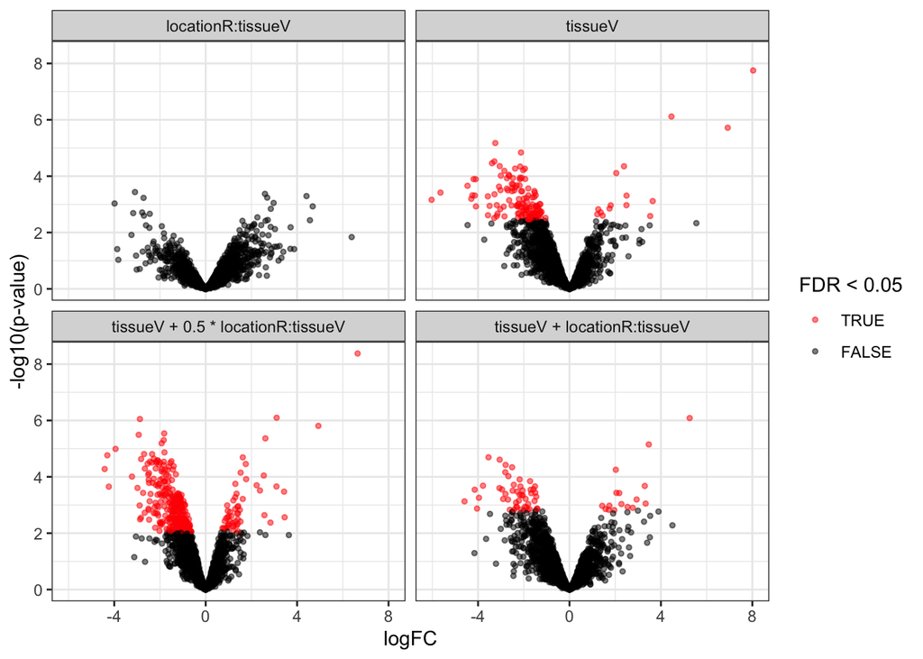

```r
volcanoplots <- inferences |>
  plotVolcano() +
  facet_wrap(~contrast)
volcanoplots
```

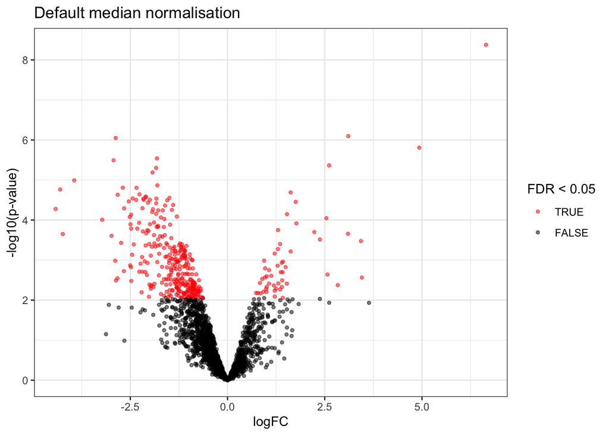

```r
 inferences |> filter(contrast == "tissueV + 0.5 * locationR:tissueV") |> plotVolcano() + ggtitle("Default median normalisation")
```

```r
pn0 <- pe[, , "peptides_log"] |>
  longForm(colvars = colnames(colData(pe))) |>
  data.frame() |>
  filter(!is.na(value)) |>
  ggplot() +
  aes(x = value,
      colour = sampleId,
      group = colname) +
  geom_density() +
  theme_minimal() +
    theme(legend.position = "NULL")+
   labs(subtitle = "Peptide intensities\nNonnormalised log2")
```

```
harmonizing input:
  removing 36 sampleMap rows not in names(experiments)
```

```r
pn1 <- pe[, , "peptides_norm"] |>
  longForm(colvars = colnames(colData(pe))) |>
  data.frame() |>
  filter(!is.na(value)) |>
  ggplot() +
  aes(x = value,
      colour = sampleId,
      group = colname) +
  geom_density() +
  theme_minimal() +
    theme(legend.position = "NULL")+
   labs(subtitle = "Peptide intensities\nNormalised log2")
```

```
harmonizing input:
  removing 36 sampleMap rows not in names(experiments)
```

```r
pn1c <-
  filterNA(pe[,,"peptides_norm"], i = "peptides_norm", pNA = 0) |>
  longForm(colvars = colnames(colData(pe))) |>
  data.frame() |>
  filter(!is.na(value)) |>
  ggplot() +
  aes(x = value,
      colour = sampleId,
      group = colname) +
  geom_density() +
  theme_minimal() +
    theme(legend.position = "NULL")+
   labs(subtitle = "Peptide intensities (complete cases)\nNormalised log2 ")
```

```
harmonizing input:
  removing 36 sampleMap rows not in names(experiments)
```

```r
pn2 <-pe[, , "peptides_norm"] |>
  longForm(colvars = colnames(colData(pe))) |>
  data.frame() |>
  filter(!is.na(value)) |>
  ggplot() +
  aes(x = sampleId,
      y = value,
      colour = sampleId,
      group = colname) +
  xlab("sample") +
  geom_boxplot() +
  theme_minimal() +
    theme(legend.position = "NULL")+
   labs(subtitle = "Peptide intensities\nNormalised log2")
```

```
harmonizing input:
  removing 36 sampleMap rows not in names(experiments)
```

```r
pn2c <-
  filterNA(pe[,,"peptides_norm"], i = "peptides_norm", pNA = 0) |>
  longForm(colvars = colnames(colData(pe))) |>
  data.frame() |>
  filter(!is.na(value)) |>
  ggplot() +
  aes(x = sampleId,
      y = value,
      colour = sampleId,
      group = colname) +
  xlab("sample") +
  geom_boxplot() +
  theme_minimal() +
    theme(legend.position = "NULL")+
   labs(subtitle = "Peptide intensities (complete cases)\nNormalised log2 ")
```

```
harmonizing input:
  removing 36 sampleMap rows not in names(experiments)
```

```r
pn3 <- pe[, , "proteins"] |>
  longForm(colvars = colnames(colData(pe))) |>
  data.frame() |>
  filter(!is.na(value)) |>
  ggplot() +
  aes(x = sampleId,
      y = value,
      colour = sampleId,
      group = colname) +
  xlab("sample") +
  geom_boxplot() +
  theme_minimal() +
    theme(legend.position = "NULL")+
   labs(subtitle = "Protein intensities\nNormalised log2")
```

```
harmonizing input:
  removing 36 sampleMap rows not in names(experiments)
```

```r
pn4 <- pe[,,"proteins"] |>
  longForm(colvars = colnames(colData(pe))) |>
  data.frame() |>
  filter(!is.na(value)) |>
  ggplot() +
  aes(x = value,
      colour = sampleId,
      group = colname) +
  geom_density() +
  theme_minimal() +
  theme(legend.position = "NULL")+
   labs(subtitle = "Protein intensities\nNormalised log2")
```

```
harmonizing input:
  removing 36 sampleMap rows not in names(experiments)
```

```r
pn4c <- filterNA(pe[,,"proteins"], i = "proteins", pNA = 0) |>
  longForm(colvars = colnames(colData(pe))) |>
  data.frame() |>
  filter(!is.na(value)) |>
  ggplot() +
  aes(x = value,
      colour = sampleId,
      group = colname) +
  geom_density() +
  theme_minimal() +
  theme(legend.position = "NULL")+
   labs(subtitle = "Protein intensities (complete cases)\nNormalised log2")
```

```
harmonizing input:
  removing 36 sampleMap rows not in names(experiments)
```

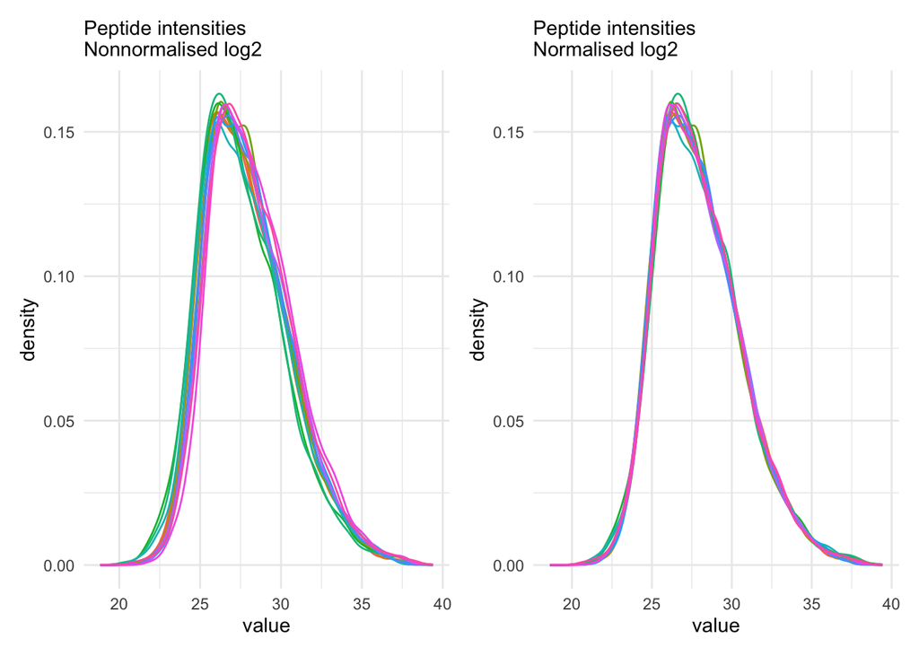

```r
pn0 + pn1
```

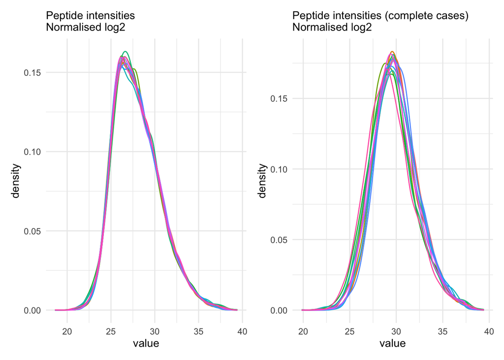

```r
pn1 + pn1c
```

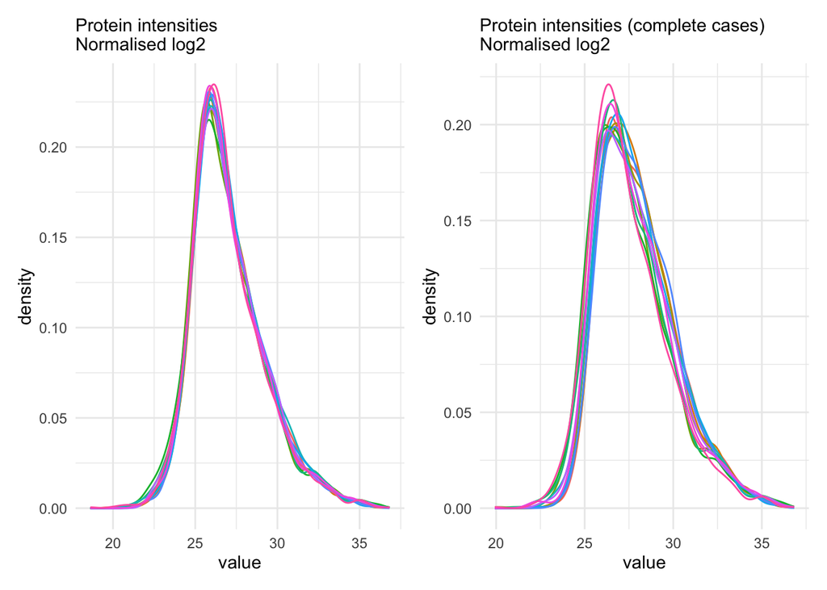

```r
pn4 + pn4c
```

### 1.7.7 Heatmaps

We use a nominal FDR level of 0.05

```r
alpha <- 0.05
```

We conduct heatmaps for the significant metabolites for each contrast.

We only produce heatmaps for the first three contrasts as no DA proteins were returned for the location x tissue interaction.

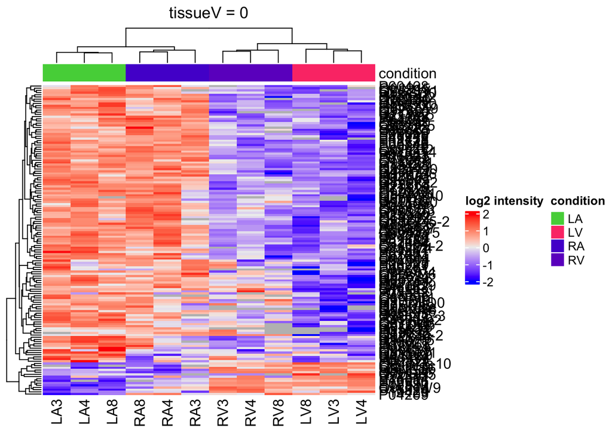

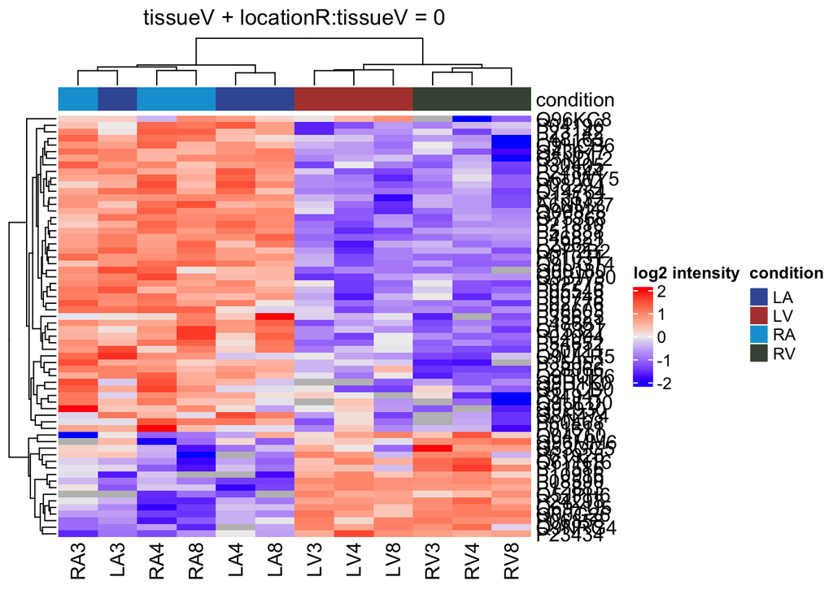

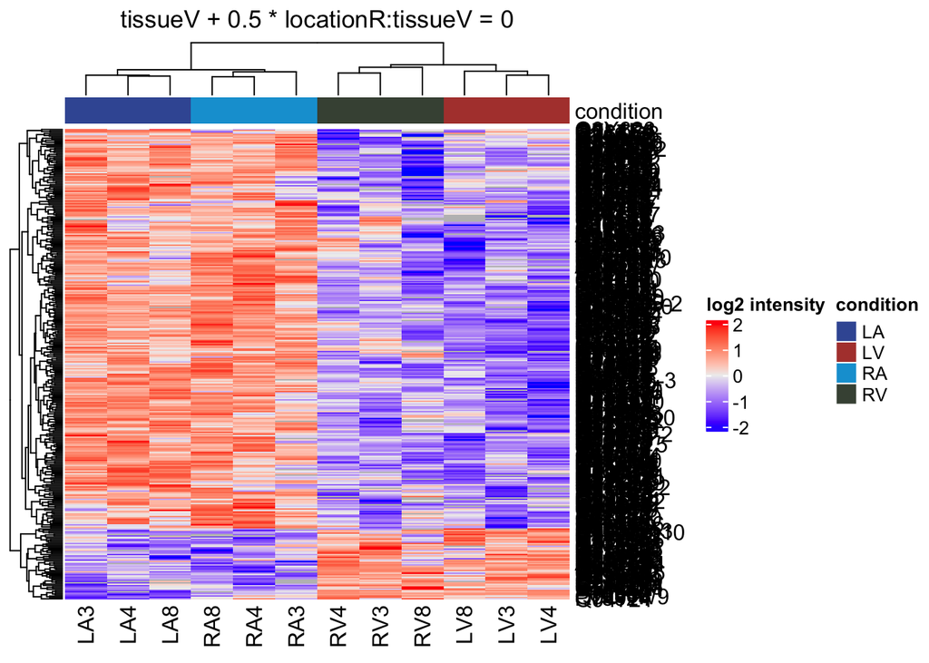

```r
heatmaps <- lapply(colnames(L)[1:3],
                   function(contrast, se, alpha)
                   {
                     sig <- rowData(se)[[contrast]] |>
                       filter(adjPval < alpha) |>
                       rownames()
                     quants <- t(scale(t(assay(se[sig,]))))
                     colnames(quants) <- paste0(se$location, se$tissue, se$patient)
                     annotations <- columnAnnotation(condition = paste0(se$location, se$tissue))
                     set.seed(1234) ## annotation colours are randomly generated by default
                     return(
                       Heatmap(
                       quants,
                       name = "log2 intensity",
                       top_annotation = annotations,
                       column_title = paste0(contrast, " = 0")
                       )
                     )
                   },
                   se = getWithColData(pe, "proteins"),
                   alpha = alpha)
heatmaps
```

## 1.8 Conclusion

In this chapter, we illustrated the analysis of a label-free proteomics data set with biological replication. We followed the workflow described in the previous chapters with minimal changes.

The experiment presented in this chapter has a complex design and is an excellent illustration of how to model data with main effects, interactions and block effects. We could investigate:

1. The difference in protein abundance between the atrium and ventriculum in the **left** heart compartment.
2. The difference in protein abundance between the atrium and ventriculum in the **right** heart compartment.
3. The difference in protein abundance between the atrium and ventriculum, **averaged** over the right and left heart compartment.
4. The interaction, whether the difference between atrium and ventriculum is affected by whether we focus on the left heart or the right heart compartment.

## Footnotes

[^1]: Note, that upon this transformation a value of 1 represents a p-value of 0.1, 2 a p-value of 0.01, 3 a p-value of 0.001, etc.